# WST Pop Model: base model review

### Background

Most important, I want to understand how S. Blackburn (Univ. of Idaho; SB) took raw CDFW data, and then created dataframes (or other data types) to ‘feed’ the model. This is an important first-step towards understanding the model. Herein I explore how SB created the base model (15% spawning periodicity) and the various methodologies used to arrive at the final results (J. DuBois, 12-Feb-2018; see original SB file `WST_midfecund_obs_basemodel.txt`).

### Data

SB creates four data variables: `initial_age_dist`; `prob_survival_obs`; `prob_spawn`; and `number_eggs`. SB begins with a WST population abundance of 48000 (slot-sized?) from CDFW reports and Hildebrand et al. (2016). Below are these four data variables.

#### Data: `initial_age_dist`

According to SB, these data are:  
1. Based on age-at-length key (NOT adjusted to trammel net selectivity) and scaled by initial_abundance (48000).  
2. Then used linear model with log-transformed count data (exponential decay fxn) to estimate age 1 and age 2 abundance. Then took 1/2 for females.  
3. Current age-0 abundance represents the number of eggs potentially in the system in a given year, which is based on number of spawning females and their associated fecundity.

```r
# create variable (matrix with 20 rows & 2 columns)
initial_age_dist <- structure(
  c(
    # age
    0, 1, 2, 3, 4, 5, 6, 7, 8, 9, 10,
    11, 12, 13, 14, 15, 16, 17, 18, 19,
    # freq
    141491743, 3192.023, 2874.605,
    743.4951, 919.6688, 1887.2559, 2643.7050,
    3778.5699,4249.9032,3177.8537,1654.6577,
    1068.1057,597.0728,1214.5035,561.4314,858.8469,
    38.1710, 439.7614,148.104767, 148.1116858
  ),
  .Dim = c(20L, 2L),
  .Dimnames = list(NULL, c("age", "freq"))
)
```

#### Data: `prob_survival_obs`

According to SB, these data are:  
1. Estimated from age-key, using Chapman-Robson peak plus one criterion and adjusted the SE for overdispersion (using chat variance inflation).  
2. Age age-0 and age-1 values are from literature.  
3. Conditional mortality, mortality in the absence of exploitation, was applied to fishes not in the harvest slot length limit.

```r
prob_survival_obs <- structure(
  list(
    # ages
    age = 0:19,
    # probabilities
    prob = c(
      0.002, 0.25, 0.835265413, 0.835265413,
      0.835265413, 0.835265413, 0.835265413,
      0.835265413, 0.835265413, 0.835265413,
      0.707049, 0.707049, 0.707049, 0.707049,
      0.707049, 0.707049, 0.835265413, 0.835265413,
      0.835265413, 0.835265413
    ),
    # standard error
    SE = c(
      0.003, 0.05, 0.0377, 0.0377, 0.0377,
      0.0377, 0.0377, 0.0377, 0.0377, 0.0377,
      0.01932, 0.01932, 0.01932, 0.01932,
      0.01932, 0.01932, 0.0377, 0.0377, 0.0377, 0.0377
    )
  ),
  .Names = c("age", "prob", "SE"),
  row.names = c(NA, -20L),
  class = "data.frame"
)
```

#### Data: `prob_spawn`

According to SB, these data are:  
1. Estimated with logistic regression from Chapman et al. 1996 summarized data. First age of maturity for females was 10 years old (~104 cm; Chapman et al. 1996).  
2. SEs predicted from the logistic model.

```r
prob_spawn <- structure(
  list(
    Age = c(
      0, 1, 2, 3, 4, 5, 6, 7, 8, 9, 10,
      11, 12, 13, 14, 15, 16, 17, 18, 19
    ),
    prob = c(
      0, 0, 0, 0, 0, 0, 0, 0, 0, 0,
      0.003726142, 0.01198, 0.021455, 0.046198, 0.078354,
      0.090394, 0.125679, 0.128829, 0.1419388, 0.144958
    ),
    SE = c(
      0, 0, 0, 0, 0, 0, 0, 0, 0, 0,
      0.00075, 0.00258, 0.00429, 0.00873,
      0.01629, 0.01866, 0.02364, 0.02547,
      0.02826,0.02898
    )
  ),
  .Names = c("Age", "prob", "SE"),
  row.names = c(NA, 20L),
  class = "data.frame"
)
```

#### Data: `number_eggs`

According to SB, these data are:  
1. From the linear regression of length on number of eggs.  
2. SEs predicted from model.

```r
number_eggs <- structure(
  list(
    Age = c(
      0, 1, 2, 3, 4, 5, 6, 7, 8, 9, 10,
      11, 12, 13, 14, 15, 16, 17, 18, 19
    ),
    count = c(
      0, 0, 0, 0, 0, 0, 0, 0, 0, 0,
      33297.98, 87236.71, 112408.1, 141175.4,
      166346.9, 191518.3, 216689.7, 267032.4994,
      313779.4042, 335354.8988
    ),
    SE = c(
      0, 0, 0, 0, 0, 0, 0, 0, 0, 0,
      11069.74, 9886.758, 8626.421, 7640.275,
      6711.24, 6144.04, 5877.155, 5951.129,
      6354.067, 7029.626
    )
  ),
  .Names = c("Age", "count", "SE"),
  row.names = c(NA, 20L),
  class = "data.frame"
)
```

### Deterministic post-Breeding Matrix Model

According to SB:  
- This model does **NOT** include stochasticity (i.e., recruitment, vital rates)  
- Last age class does NOT die

A post-breeding census means we capture newborns in our census, they are 1st age class  
- Row 1: how do we get new age-0 individuals in the next time step?  
- Animals we catch right AFTER (post) their birthday can contribute newborn (age 0) animals to next year’s census by surviving to their next birthday, then reproducing ON that birthday.  
- Ex: fecundity of 9-year-olds (10th fecundity row element in matrix) is: survival from 9-10 (i.e., S9, 10th survival element), times fecundity on 10th bday (i.e., f10, 11th repro element)

```r
# create breeding matrix
A <- matrix(
  data = rep(0, times = 19 *20),
  byrow = TRUE,
  nrow = 19
)

# f0-f19; 50% sex ratio
fecundity <- number_eggs$count[2:20] * prob_spawn$prob[2:20] * 0.5

# need to add f20, same as f19
fecundity <- c(fecundity, fecundity[19])

row1 <- prob_survival_obs$prob * fecundity

# Survival probablities of ages 0-19
p.surv.obs = prob_survival_obs$prob[1:19]

# Manually add 19+ age class so that last age class does not die
p.surv.obs.final = prob_survival_obs$prob[20]


diag(A) <- p.surv.obs

A[19, 20] <- p.surv.obs.final
A <- rbind(row1, A)
```

```r
# Eigen values
ev <- eigen(A)

# Absolute value of eigen values
Mod <- ev$values

# Position of primary eigen value
lmax <- which.max(Re(ev$values))

# Primary eigen value 1.050753; does NOT include recruitment stochasicity
# (later)
Re(ev$values)[lmax]
```

```
## [1] 1.050753
```

```r
# can also get lambda below
popbio::lambda(A)
```

```
## [1] 1.050753
```

```r
# Create stable age distribition (SAD) for easy comparasion to transient (i.e.,
# intitial_age_dist) dymanics

# SAD should be higher than transient dymanics because it negates
# cohort/year-class effects
SAD <- popbio::eigen.analysis(A)$stable.stage
stable_age_dist <- 10000 * SAD
stable_age_dist
```

```
##         row1
## 9.960234e+03 1.895827e+01 4.510639e+00 3.585600e+00 2.850267e+00
##
## 2.265736e+00 1.801080e+00 1.431716e+00 1.138100e+00 9.046995e-01
##
## 7.191643e-01 4.839237e-01 3.256309e-01 2.191162e-01 1.474427e-01
##
## 9.921378e-02 6.676068e-02 5.306944e-02 4.218599e-02 1.635197e-01
```

#### Practice Simulation

SB creates a practice simulation below. Mostly, it changes the number of iterations (see `iters` variable) for the function `pop.projection()` in the `popbio` package. To get a sense of what this function does, I demo it below SB’s code.

```r
# iteration variable
iters <- c(20, 100, 1000, 10000)

# variable to hold lambdas and CIs
my_lambdas <- c()
my_lambdas_CIs <- c()

for (i in 1:length(iters)) {
  determ_proj <- popbio::pop.projection(
    A = A,
    n = initial_age_dist[, 2], # column 2 is frequency
    iterations = iters[i]
  )

  my_log_lambdaS <- mean(log(determ_proj$pop.changes))

  # my note (15-Feb-2018): no log taken of determ_proj$pop.changes
  my_log_lambdaS_SE <- 1.96 * sqrt(var(determ_proj$pop.changes / iters[i]))

  my_log_lambdaS_CI <- c(
    my_log_lambdaS - my_log_lambdaS_SE,
    my_log_lambdaS + my_log_lambdaS_SE
  )

  my_lambdas <- c(my_lambdas, exp(my_log_lambdaS))
  my_lambdas_CIs <- rbind(my_lambdas_CIs, exp(my_log_lambdaS_CI))
}
# end for loop

mean(my_lambdas)
```

```
## [1] 1.027567
```

*Demo of `pop.projection()`*

```r
# uses 20 iterations for simplicity
det_proj <- popbio::pop.projection(
    A = A,
    # column 2 is frequency
    n = initial_age_dist[, 2],
    iterations = 20
  )

# det_proj is a list of 5 elements
# (1) lambda as pop[t] / pop[t - 1], where t = iterations, or the final
#     two values in pop.sizes
# (2) stable.stage: est. of stable stage distribution
# (3) stage.vector: matrix w/ # of projected individuals in each stage class
# (4) pop.sizes: total number of projected individuals
# (5) pop.changes: proportional change in population size

# not sure in this context I understand the purpose of taking log()
det_proj$pop.changes
```

```
##  [1] 0.2502216 1.0415416 1.0700979 1.0448354 1.0304648 0.9960838 0.9714282
##  [8] 0.9608737 0.9545231 0.9645591 1.0694339 1.0532915 1.1961103 1.1947964
## [15] 1.0433744 1.1218728 1.1071264 1.1183041 1.0542626
```

```r
cat("\n")
```

```r
log(det_proj$pop.changes)
```

```
##  [1] -1.385408515  0.040701920  0.067750137  0.043859362  0.030009953
##  [6] -0.003923938 -0.028987887 -0.039912337 -0.046543486 -0.036084142
## [11]  0.067129481  0.051920059  0.179074901  0.177975777  0.042460082
## [16]  0.114999400  0.101767872  0.111813384  0.052841575
```

### Stochastic Matrix Model

Here SB calculates stochastic log growth rate by simulation (an approach outlined pg. 234 Morris & Doak; same approach also used by Ng & Syslo in their respective theses).

The approach — as SB writes — has 7 main steps.

Let’s look at each step…

#### Step 1: simulate `iid` vital rates

##### Observed Survival Rates

In `prob_survival_obs` we have observed survival rates and standard deviations (assuming `SE` is standard deviation; see ‘Questions’ section).

```r
# establish variable with number of iterations; SB we set iters to 5000 for
# final runs of model; my note: writes over previously established iters
# variable
iters <- 100

# establish variable to hold for loop results
surv_obs_sims <- c()

# create for loop to run through each row of prob_survival_obs
for (i in 1:20) {
  age_sims <- replicate(
    n = iters,
    expr = popbio::betaval(
      # observed survival rates
      mn = prob_survival_obs[i, 2],
      # standard deviations (or standard errors?)
      sdev = prob_survival_obs[i, 3]
    )
  )

  surv_obs_sims <- rbind(surv_obs_sims, age_sims)
}
# end for loop

# not displayed due to size (large matrix) - where row = age & column =
# simulations
dim(surv_obs_sims)
```

```
## [1]  20 100
```

Here SB “simulates environmental stochasticity for age-0 survival only. WST only having successful recruitment every 5 years (on average).”

DuBois: Is simulation on age-0 only for recruitment purposes?  
DuBois: Successful recruitment every 5 or 7 years (on average)? Not clear from annotations.

return to questions

```r
# isolate age-0 simulated survival
recruit_rate <- surv_obs_sims[1, ]

# on avg. successful recruitent every 7 years; recruit_dat now has 700 values
recruit_dat <- c(rep(0, times = iters * 6), recruit_rate)

# randomnly sample from recruit_dat; sample size = number of iterations
V <- sample(recruit_dat, size = iters, replace = TRUE)

# replace age-0 simulated survival rates
surv_obs_sims[1, ] <- V

# check to make sure new vector was succesfully added
# not run due to size
# head(surv_obs_sims)

# just FIO
# typeof(recruit_dat)
# str(recruit_dat)
# surv_obs_sims[1, ]
```

Check the simulations against the observed values in `prob_survival_obs`.

```r
surv_obs_check <- cbind(
  prob_survival_obs,
  sim_prob = round(apply(surv_obs_sims, MARGIN = 1, FUN = mean), digits = 4),
  sim_SE = round(apply(surv_obs_sims, MARGIN = 1, FUN = sd), digits = 4)
)

# view to ensure 20 ages classes (0 --> 19) are present; ages 20+ will be added
# later in the process
surv_obs_check
```

| age | prob | SE | sim_prob | sim_SE |
| --- | --- | --- | --- | --- |
| 0 | 0.0020000 | 0.00300 | 0.0004 | 0.0013 |
| 1 | 0.2500000 | 0.05000 | 0.2424 | 0.0465 |
| 2 | 0.8352654 | 0.03770 | 0.8400 | 0.0401 |
| 3 | 0.8352654 | 0.03770 | 0.8329 | 0.0408 |
| 4 | 0.8352654 | 0.03770 | 0.8340 | 0.0393 |
| 5 | 0.8352654 | 0.03770 | 0.8311 | 0.0364 |
| 6 | 0.8352654 | 0.03770 | 0.8361 | 0.0372 |
| 7 | 0.8352654 | 0.03770 | 0.8415 | 0.0345 |
| 8 | 0.8352654 | 0.03770 | 0.8350 | 0.0387 |
| 9 | 0.8352654 | 0.03770 | 0.8397 | 0.0371 |

[output cut: 10 more lines]

```r
# just FIO
# plot(prob ~ sim_prob, data = surv_obs_check)
```

##### Probability of Spawning

Here we repeat the process above except using `prob_spawn` instead of `prob_survival_obs`.

```r
prob_spawn_sim <- c()

# loop through each row (or age class)
for (i in 1:20) {
  spawn_sims <- replicate(
    n = iters,
    expr = popbio::betaval(
      # probability of spawning
      mn = prob_spawn[i, 2],
      # standard deviation
      sdev = prob_spawn[i, 3]
    )
  )

  prob_spawn_sim <- rbind(prob_spawn_sim, spawn_sims)
}
# end for loop

# result is matrix num of rows = age classes, num of columns = iters
dim(prob_spawn_sim)
```

```
## [1]  20 100
```

Again, we check simulated against observed.

```r
prob_spawn_check <- cbind(
  prob_spawn,
  sim_prob = round(apply(prob_spawn_sim, MARGIN = 1, FUN = mean), digits = 4),
  sim_SE = round(apply(prob_spawn_sim, MARGIN = 1, FUN = sd), digits = 4)
)

# display dataframe
prob_spawn_check
```

| Age | prob | SE | sim_prob | sim_SE |
| --- | --- | --- | --- | --- |
| 0 | 0.000000000 | 0.00000 | 0.0000 | 0.0000 |
| 1 | 0.000000000 | 0.00000 | 0.0000 | 0.0000 |
| 2 | 0.000000000 | 0.00000 | 0.0000 | 0.0000 |
| 3 | 0.000000000 | 0.00000 | 0.0000 | 0.0000 |
| 4 | 0.000000000 | 0.00000 | 0.0000 | 0.0000 |
| 5 | 0.000000000 | 0.00000 | 0.0000 | 0.0000 |
| 6 | 0.000000000 | 0.00000 | 0.0000 | 0.0000 |
| 7 | 0.000000000 | 0.00000 | 0.0000 | 0.0000 |
| 8 | 0.000000000 | 0.00000 | 0.0000 | 0.0000 |
| 9 | 0.000000000 | 0.00000 | 0.0000 | 0.0000 |

[output cut: 10 more lines]

##### Number of Eggs

Using data in `num_eggs` simulate number of eggs, again with `for()` loop but this time using `popbio::stretchbetaval()`.

```r
# variable to hold simulations
num_eggs_sim <- c()

# loop through rows (that is ages)
for (i in 1:20) {
  eggs_sims <- replicate(
    n = iters,
    expr = popbio::stretchbetaval(
      # count
      mn = number_eggs[i, 2],
      # standard deviation
      std = number_eggs[i, 3],
      minb = 0,
      maxb = 3 * number_eggs[i, 2],
      fx = runif(1)
    )
  )

  num_eggs_sim <- rbind(num_eggs_sim, eggs_sims)
}

# check for 20 x 100
dim(num_eggs_sim)
```

```
## [1]  20 100
```

Check the simulations

```r
num_eggs_check <- cbind(
  round(number_eggs, digits = 4),
  sim_num = round(apply(num_eggs_sim, MARGIN = 1, FUN = mean), digits = 4),
  sim_SE = round(apply(num_eggs_sim, MARGIN = 1, FUN = sd), digits = 4)
)

num_eggs_check
```

| Age | count | SE | sim_num | sim_SE |
| --- | --- | --- | --- | --- |
| 0 | 0.00 | 0.000 | 0.00 | 0.000 |
| 1 | 0.00 | 0.000 | 0.00 | 0.000 |
| 2 | 0.00 | 0.000 | 0.00 | 0.000 |
| 3 | 0.00 | 0.000 | 0.00 | 0.000 |
| 4 | 0.00 | 0.000 | 0.00 | 0.000 |
| 5 | 0.00 | 0.000 | 0.00 | 0.000 |
| 6 | 0.00 | 0.000 | 0.00 | 0.000 |
| 7 | 0.00 | 0.000 | 0.00 | 0.000 |
| 8 | 0.00 | 0.000 | 0.00 | 0.000 |
| 9 | 0.00 | 0.000 | 0.00 | 0.000 |

[output cut: 10 more lines]

##### Fecundity

Simulate fecundity rate from `prob_spawning_sims` & `number_eggs_sims`

```r
# assumes 50% sex ratio
fecund_sim <- num_eggs_sim * prob_spawn_sim * 0.5

# check to make sure fecundity look right - should be 20 x 100
# tail(fecund_sim)
dim(fecund_sim)
```

```
## [1]  20 100
```

#### Step 2: make random projection matrices

Here SB creates post-breeding Leslie matrices, which include WST caught right **AFTER** (post) their “birthday” (i.e., Jan 1)

DuBois: Is “caught” referring to in CDFW trammel nets, or by anglers or both? Or something else?

return to questions

```r
random_matrices <- list()

for (i in 1:iters) {

  # 20 columns by 19 rows; will add top extra row (fecundity)
  A <- matrix(data = rep(0, times = 19 * 20), byrow = TRUE, nrow = 19)

  # for simplicity A can be
  # A <- matrix(data = 0, nrow = 19, ncol = 20)

  # survival rates age 0 through 19
  diag(A) <- surv_obs_sims[1:19, i]

  # last age class does NOT die
  A[19, 20] <- popbio::betaval(
    mn = prob_survival_obs[20, 2],
    sdev = prob_survival_obs[20, 3]  )

  # add new element to list
  random_matrices[[i]] <- as.matrix(
    rbind(fecund_sim[, i] * surv_obs_sims[, i], A)
  )
}
# end for loop

# make sure structure looks right
# head(random_matrices)

# random_matrices s/b list w/ 100 elements each element is 20x20 matrix

# run FIO
# length(random_matrices)
# Map(f = dim, random_matrices)
```

#### Step 3: Apply function `popbio::pop.projection()`

For each element in `random_matrices` (n=100) apply `popbio::pop.projection()`.

DuBois: Should column 2 (`freq`) be selected for `initial_age_dist` below?

return to questions

```r
# set number of years over which to perform projection
period <- 20

sim_projections <- lapply(
  seq_along(random_matrices),
  FUN = function(i) {
    popbio::pop.projection(
      A = random_matrices[[i]],
      n = initial_age_dist,
      iterations = period
    )
  }
)

# for simplicity sim_projections can be this
# sim_projections <- lapply(
#   random_matrices,
#   FUN = popbio::pop.projection,
#   n = initial_age_dist,
#   iterations = period
# )
```

#### Step 4: Calculate mean log lambdas

For each element in `sim_projections`, get the average log-lambda to look at “sampling distribution” of the log lambdas.

SB notes an aside that Cox calculated mean of *theoretical* lambdas. But SB says not to use these in final analysis. See SB’s `.txt` file for code.

DuBois: Why apply log in this manner?

return to questions

```r
# just the lambdas
log_lambdaS <- sapply(seq_along(sim_projections), FUN = function(i) {
  mean(log(sim_projections[[i]]$pop.changes))
})

# for simplicity log_lambdaS can be this
# log_lambdaS <- vapply(
#   sim_projections,
#   FUN = function(x) mean(log(x[["pop.changes"]])),
#   FUN.VALUE = numeric(1L)
# )

mean(log_lambdaS)
```

```
## [1] -0.1304931
```

#### Step 5: Calculate geometric mean of lambdas

Geometric mean is just the mean of the log lambdas, exponentiated.

DuBois: `exp` and then `mean` OR `mean` then `exp`?

return to questions

```r
mean_lambdaS <- exp(mean(log_lambdaS))

# Presumably we can find the 95% CIs in the same way:
LB_lambdaS <- exp(quantile(log_lambdaS, probs = 0.025))
UB_lambdaS <- exp(quantile(log_lambdaS, probs = 0.975))

c(LB_lambdaS, Mean = mean_lambdaS, UB_lambdaS)
```

```
##      2.5%      Mean     97.5%
## 0.8252588 0.8776625 1.0030370
```

#### Step 6: sensitivity & elasticity analysis

DuBois (note-to-self): need to look at help file for `popbio::stoch.sens()`.

This gets at the elasticity - what vital rate has greatest influece over pop rate.

```r
sens <- popbio::stoch.sens(A = random_matrices, tlimit = 100)

# big list
# sens

names(sens)
```

```
## [1] "sensitivities" "elasticities"
```

```r
str(sens)
```

```
## List of 2
##  $ sensitivities: num [1:20, 1:20] 3.46e-02 5.66e+02 2.14e+03 2.28e+03 2.46e+03 ...
##  $ elasticities : num [1:20, 1:20] 0 0.024 0 0 0 ...
##   ..- attr(*, "dimnames")=List of 2
##   .. ..$ : NULL
##   .. ..$ : chr [1:20] "eggs_sims" "eggs_sims" "eggs_sims" "eggs_sims" ...
```

#### Step 7: lambdas over time

`sim_projections` is a list with 100 elements. Each item contains 5 items. We want the `pop.changes` (lambda, $\lambda$) item from each element.

DuBois: The x-axis is labeled as ‘Year’ but should be ‘Age’ in this context, correct? Or maybe it refers to year of fishes life? For instance, `1` is first year of sturgeon’s life.

return to questions

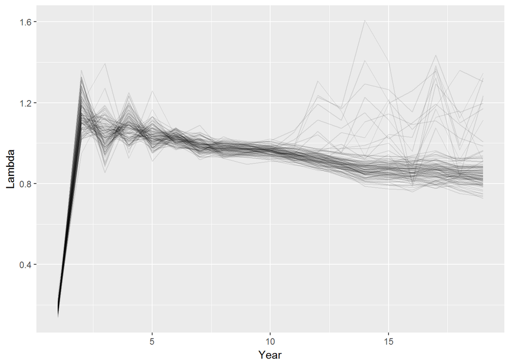

```r
# herein I simplified a bit of the code & used ggplot (J. DuBois)

library(ggplot2)

# combine 100 pop.changes outputs to matrix for convenience of plotting
lambdas_time <- do.call(
  what = rbind,
  args = Map(f = function(x) x[["pop.changes"]], sim_projections)
)

ggplot(
  data = reshape::melt.matrix(data = lambdas_time),
  mapping = aes(x = X2, y = value)
) +
  geom_line(mapping = aes(group = X1), alpha = 1/10) +
  labs(x = "Year", y = "Lambda")
```

Not sure I understand SB’s code below. `lambdas.time` has 100 rows & only 19 columns. So `40:ncol(lambdas.time)` will error as subscript out-of-bounds. Should the matrix be reversed? Note: typo in references to `MeanLambdas5`, should be `MeanLambdas15`, I believe.

```r
# not evaluated

## Take the lambdas from year 2 on ##
lambdas2 <-lambdas.time[,2:ncol(lambdas.time)]

# Geometric mean for each iteration from year 2 on...
MeanLambdas2 <-c()
for(i in 1:nrow(lambdas2)){
  MeanLambdas2[i]<-exp(mean(log(lambdas2[i,])))
}
mean(MeanLambdas2)

## Take the lambdas from year 15 on ##
lambdas15 <-lambdas.time[,15:ncol(lambdas.time)]

# Geometric mean for each iteration from year 15 on...
MeanLambdas15 <-c()
for(i in 1:nrow(lambdas15)){
  MeanLambdas5[i]<-exp(mean(log(lambdas5[i,])))
}
mean(MeanLambdas15)

## Now take the lambdas from year 40 on ##
lambdas40 <-lambdas.time[,40:ncol(lambdas.time)]

# Geometric mean for each iteration from year 40 on...
MeanLambdas40 <-c()
for(i in 1:nrow(lambdas40)){r
  MeanLambdas40[i]<-exp(mean(log(lambdas40[i,])))
}
mean(MeanLambdas40)
```

### Questions

**female spawing once ever 6 years; THIS FILE NOT CORRECTED FOR GEAR SELECTIVITY**

Click on “context” (when available) to see question within section (context) of document.

1. Can all initial (starting) data be class `data.frame`? `initial_age_dist` is a matrix.  
   *correct*
2. Are we assuming a 50% sex ratio?  
   *correct; just stuck with this throughout modeling*
3. Variable `A` is a Leslie Matrix, yes? *yes*
4. For the practice simulation of the deterministic model, why is it necessary to take the log of the `pop.changes` vector?  
   *gets lambda, eigen values*
5. Some very large values in `determ_proj$pop.sizes`. Any explanation?  
   *artifact of starting population*
6. Is simulation on age-0 only for recruitment purposes? context  
   *model pre & post breeding census; pre don’t need to have age0 included; mostly for stochastic model*
7. Successful recruitment every 5 or 7 years (on average)? Not clear from annotations. context *every 6 years, but she changed to 8 years*
8. Is “caught” referring to in CDFW trammel nets, or by anglers or both? Or something else? context  
   *refers to catching (sampling) newborns after Jan 1st*
9. Should column 2 (`freq`) be selected for `initial_age_dist`? context  
   *could be but needs more investigation*
10. Why apply log in this manner? context *to get geometric mean*
11. `exp` and then `mean` OR `mean` then `exp`? context *apply mean and then exp*
12. The x-axis is labeled as ‘Year’ but should be ‘Age’ in this context, correct? Or maybe it refers to year of fishes life? For instance, `1` is first year of sturgeon’s life. context  
    *discarded this figure*

return to top

ran: 2018-02-28 13:26:04  
CDFW, Sportfish unit